# Tarea 10_Ricardo Zamora Mennigke_Mineria de Datos I

Ricardo Zamora Mennigke

6/3/2020

#Tarea 10 #Mineria de Datos I #Ricardo Zamora Mennigke

```r
library(tidyverse)
```

```r
library(ggplot2)
library(dplyr)
library(glue)
library(scales)
library(xgboost)
library(randomForest)
```

Ejercicio 1: [25 puntos] En esta pregunta utiliza los datos (tumores.csv). Se trata de un conjunto de datos de caracter´ısticas del tumor cerebral que incluye cinco variables de primer orden y ocho de textura y cuatro par´ametros de evaluaci´on de la calidad con el nivel objetivo. La variables son: Media, Varianza, Desviaci´on est´andar, Asimetr´ıa, Kurtosis, Contraste, Energ´ıa, ASM (segundo momento angular), Entrop´ıa, Homogeneidad, Disimilitud, Correlaci´on, Grosor, PSNR (Pico de la relaci´on se˜nal-ruido), SSIM (´Indice de Similitud Estructurada), MSE (Mean Square Error), DC (Coeficiente de Dados) y la variable a predecir tipo (1 = Tumor, 0 = No-Tumor).

1. Cargue la tabla de datos tumores.csv en R y ejecute un str(…), summary(…) y un dim(…), verifique la correcta lectura de los datos.

```r
setwd("C:/Users/rzamoram/Documents/Machine Learning/Mineria de Datos I/Clase2")
datos<-read.csv("tumores.csv",dec='.',header=T)
head(datos)
```

```
##   imagen     media  varianza desviacion.estandar  entropia asimetria  kurtosis
## 1 Image1 23.448517 2538.9856            50.38835 0.6511741  1.984202  5.421042
## 2 Image2  4.398331  834.8530            28.89382 0.9535317  6.495203 43.349355
## 3 Image3  3.244263  642.0592            25.33889 0.9660645  7.772860 61.756034
## 4 Image4  8.511353 1126.2142            33.55911 0.8687651  3.763142 15.107579
## 5 Image5 21.000793 2235.3170            47.27914 0.6847244  1.936029  4.722343
## 6 Image7 11.350555  998.9722            31.60652 0.7611065  2.533920  7.394586
##   contraste   energia       asm homogeneidad disiminitud correlacion      psnr
## 1 181.46771 0.7815569 0.6108312    0.8470333   2.7654114   0.9685761  97.97463
## 2  76.74589 0.9727695 0.9462805    0.9807616   0.5486053   0.9597505 110.34660
## 3  81.75241 0.9801609 0.9607154    0.9850659   0.5404114   0.9442587 112.26630
## 4 362.29121 0.9217862 0.8496899    0.9492953   2.7657252   0.8590271 101.95579
## 5 312.43923 0.8041836 0.6467113    0.8803008   3.0066597   0.9385719  97.63987
## 6 303.94798 0.8542768 0.7297889    0.9023554   3.4405509   0.8664795  99.20658
##        ssim         mse        dc tipo
## 1 0.7770111 0.171163194 0.3039887    1
## 2 0.9779528 0.009913194 0.8390189    1
## 3 0.9853620 0.006371528 0.8497749    1
## 4 0.8810152 0.068437500 0.0000000    0
## 5 0.7663084 0.184878472 0.0000000    0
## 6 0.7948807 0.128888889 0.0000000    0
```

```r
library(caret)
```

```r
datos$tipo <- factor(datos$tipo,ordered = TRUE)
datos$imagen <- as.integer(datos$imagen,ordered = TRUE)
summary(datos)
```

```
##      imagen           media              varianza        desviacion.estandar
##  Min.   :   1.0   Min.   : 0.001541   Min.   :   0.156   Min.   : 0.3945
##  1st Qu.: 319.5   1st Qu.: 0.381950   1st Qu.:  58.557   1st Qu.: 7.6523
##  Median : 638.0   Median : 1.826401   Median : 280.429   Median :16.7460
##  Mean   : 638.0   Mean   : 4.029659   Mean   : 486.384   Mean   :18.3179
##  3rd Qu.: 956.5   3rd Qu.: 4.974586   3rd Qu.: 707.677   3rd Qu.:26.6022
##  Max.   :1275.0   Max.   :31.031021   Max.   :3345.854   Max.   :57.8434
##     entropia        asimetria          kurtosis          contraste
##  Min.   :0.5307   Min.   :  1.219   Min.   :    2.50   Min.   :  0.3557
##  1st Qu.:0.9326   1st Qu.:  5.437   1st Qu.:   30.57   1st Qu.: 20.7866
##  Median :0.9757   Median :  9.377   Median :   88.95   Median : 50.4217
##  Mean   :0.9344   Mean   : 16.996   Mean   :  742.22   Mean   : 75.0515
##  3rd Qu.:0.9943   3rd Qu.: 20.320   3rd Qu.:  415.83   3rd Qu.: 97.1238
##  Max.   :0.9999   Max.   :255.995   Max.   :65534.24   Max.   :743.3681
##     energia            asm          homogeneidad     disiminitud
##  Min.   :0.6959   Min.   :0.4843   Min.   :0.8111   Min.   :0.003522
##  1st Qu.:0.9603   1st Qu.:0.9223   1st Qu.:0.9730   1st Qu.:0.150540
##  Median :0.9858   Median :0.9718   Median :0.9895   Median :0.415167
##  Mean   :0.9600   Mean   :0.9257   Mean   :0.9739   Mean   :0.704138
##  3rd Qu.:0.9967   3rd Qu.:0.9934   3rd Qu.:0.9975   3rd Qu.:0.821914
##  Max.   :1.0000   Max.   :0.9999   Max.   :1.0000   Max.   :5.604428
##   correlacion              psnr             ssim             mse
##  Min.   :-0.0000349   Min.   : 53.38   Min.   :0.6760   Min.   :0.0002257
##  1st Qu.: 0.8308350   1st Qu.: 62.04   1st Qu.:0.9369   1st Qu.:0.0118142
##  Median : 0.9001476   Median : 64.94   Median :0.9612   Median :0.0235417
##  Mean   : 0.8650773   Mean   : 68.90   Mean   :0.9395   Mean   :0.0424071
##  3rd Qu.: 0.9419782   3rd Qu.: 68.75   3rd Qu.:0.9773   3rd Qu.:0.0440017
##  Max.   : 0.9901755   Max.   :123.29   Max.   :0.9993   Max.   :0.2986979
##        dc          tipo
##  Min.   :0.00000   0:  97
##  1st Qu.:0.08947   1:1178
##  Median :0.36098
##  Mean   :0.38858
##  3rd Qu.:0.65969
##  Max.   :0.95797
```

```r
str(datos)
```

```
## 'data.frame':    1275 obs. of  18 variables:
##  $ imagen             : int  1 614 698 790 871 1030 1108 1194 2 85 ...
##  $ media              : num  23.45 4.4 3.24 8.51 21 ...
##  $ varianza           : num  2539 835 642 1126 2235 ...
##  $ desviacion.estandar: num  50.4 28.9 25.3 33.6 47.3 ...
##  $ entropia           : num  0.651 0.954 0.966 0.869 0.685 ...
##  $ asimetria          : num  1.98 6.5 7.77 3.76 1.94 ...
##  $ kurtosis           : num  5.42 43.35 61.76 15.11 4.72 ...
##  $ contraste          : num  181.5 76.7 81.8 362.3 312.4 ...
##  $ energia            : num  0.782 0.973 0.98 0.922 0.804 ...
##  $ asm                : num  0.611 0.946 0.961 0.85 0.647 ...
##  $ homogeneidad       : num  0.847 0.981 0.985 0.949 0.88 ...
##  $ disiminitud        : num  2.765 0.549 0.54 2.766 3.007 ...
##  $ correlacion        : num  0.969 0.96 0.944 0.859 0.939 ...
##  $ psnr               : num  98 110.3 112.3 102 97.6 ...
##  $ ssim               : num  0.777 0.978 0.985 0.881 0.766 ...
##  $ mse                : num  0.17116 0.00991 0.00637 0.06844 0.18488 ...
##  $ dc                 : num  0.304 0.839 0.85 0 0 ...
##  $ tipo               : Ord.factor w/ 2 levels "0"<"1": 2 2 2 1 1 1 2 2 2 2 ...
```

```r
dim(datos)
```

```
## [1] 1275   18
```

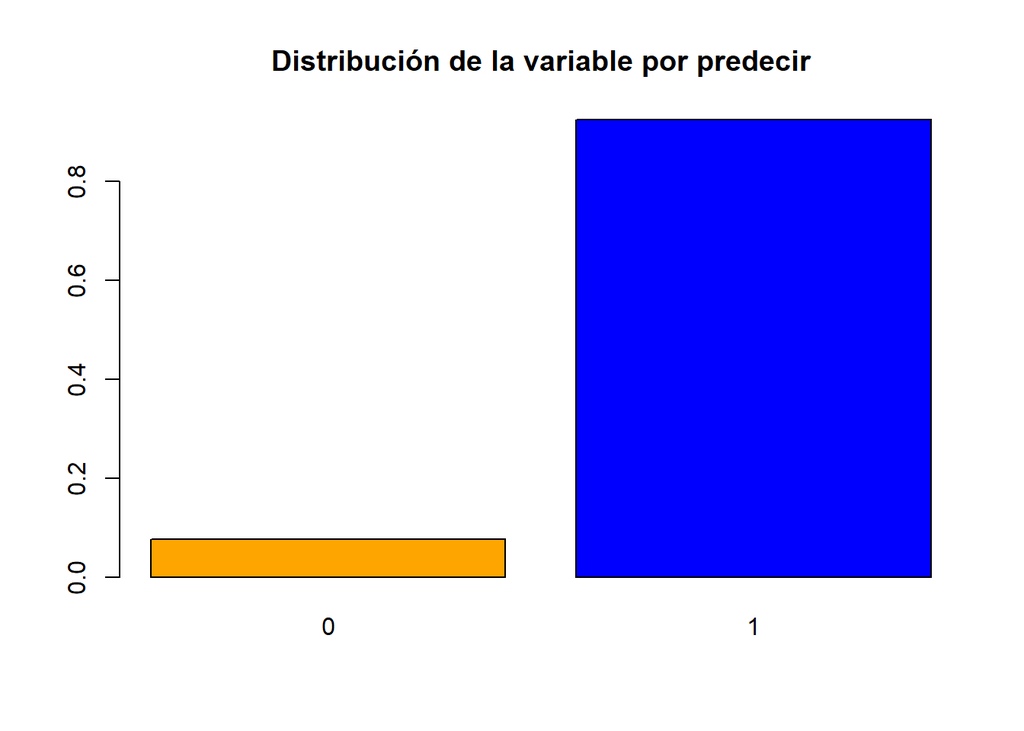

```r
barplot(prop.table(table(datos$tipo)),col=c("orange","blue","green"),main="Distribución de la variable por predecir")
```

Ejercicio desbalanceado

```r
intrain <- createDataPartition(
  y = datos$tipo,
  p = .75,
  list = FALSE
)
str(intrain)
```

```
##  int [1:957, 1] 1 2 3 4 5 6 7 8 10 11 ...
##  - attr(*, "dimnames")=List of 2
##   ..$ : NULL
##   ..$ : chr "Resample1"
```

```r
taprendizaje <- datos[ intrain,]
ttesting  <- datos[-intrain,]

nrow(taprendizaje)
```

```
## [1] 957
```

```r
nrow(ttesting)
```

```
## [1] 318
```

```r
library(traineR)
```

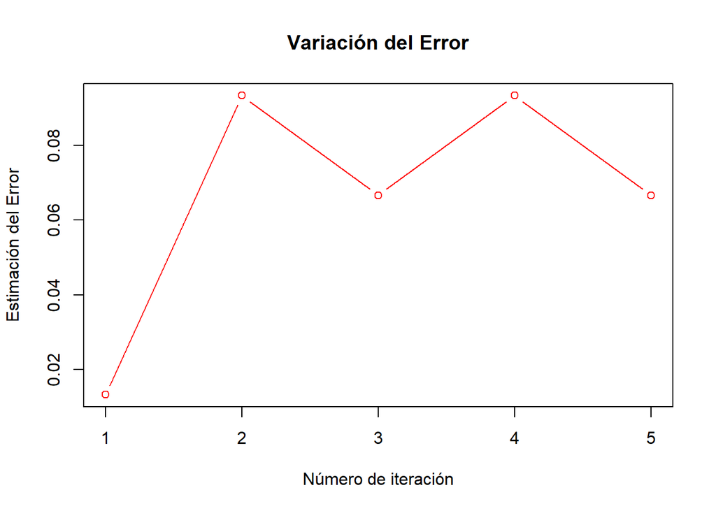

```r
v.error.tt<-rep(0,5)
for(i in 1:5) {
  muestra <- sample(1:150,75)
  ttesting <- datos[muestra,]
  taprendizaje <- datos[-muestra,]

  # modelo <- train.kknn(tipo~.,data=taprendizaje,kmax=10)
  modelo <- train.knn(tipo~.,data=taprendizaje,kmax=50)

  #prediccion <- predict(modelo,ttesting[,-5])
  prediccion <- predict(modelo,ttesting,type = "class")

  ## Matriz de Confusión
  # MC<-table(ttesting[,5],prediccion)
  MC <- confusion.matrix(ttesting, prediccion)
  # Porcentaje de buena clasificacion y de error
  acierto<-sum(diag(MC))/sum(MC)
  error <- 1- acierto
  v.error.tt[i] <- error
}
plot(v.error.tt,col="red",type="b",main="Variación del Error",xlab="Número de iteración",ylab="Estimación del Error")
```

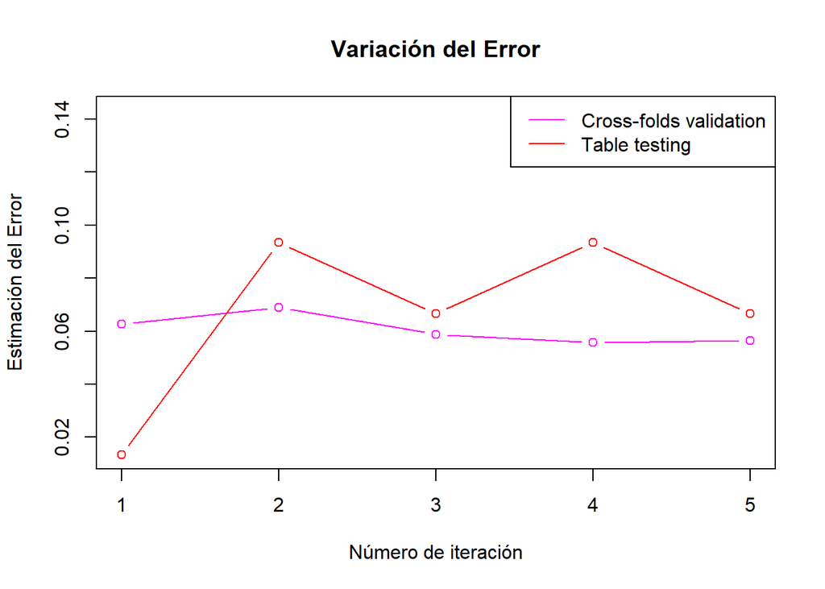

```r
suppressMessages(library(caret)) # Este paquete es usado para generar los grupos al azar

n <- dim(datos)[1] # Aquí n=150
## Vamos a generar el modelo dejando un grupo para testing y los demás datos para aprendizaje.
v.error.kg<-rep(0,5)
# Hacemos validación cruzada 5 veces para ver que el error se estabiliza
for(i in 1:5) {
  errori <- 0
  # Esta instrucción genera los k=5 grupos (Folds)
  grupos <- createFolds(1:n,5) # grupos$Fold0i es el i-ésimo grupo
  # Este ciclo es el que hace "cross-validation" (validación cruzada) con 5 grupos (Folds)
  for(k in 1:5) {
      muestra <- grupos[[k]] # Por ser una lista requiere de doble paréntesis
      ttesting <- datos[muestra,]
      taprendizaje <- datos[-muestra,]
      modelo <- train.knn(tipo~.,data=taprendizaje,kmax=50)
      prediccion <- predict(modelo,ttesting,type = "class")
      MC <- confusion.matrix(ttesting, prediccion)
      # Porcentaje de buena clasificación y de error
      acierto<-sum(diag(MC))/sum(MC)
      error <- 1 - acierto
      errori <- errori + error
  }
  v.error.kg[i] <- errori/5
}
plot(v.error.kg, col = "magenta", type = "b", ylim = c(min(v.error.kg,v.error.tt), max(v.error.kg,v.error.tt) + 0.05), main = "Variación del Error", xlab = "Número de iteración", ylab = "Estimación del Error")
points(v.error.tt, col = "red", type = "b")
legend("topright", legend = c("Cross-folds validation", "Table testing"), col = c("magenta","red"), lty = 1, lwd = 1)
```

4. ¿Que se puede concluir?

Ejercicio 2: [25 puntos] Para esta pregunta tambi´en usaremos los datos tumores.csv.

1. El objetivo de este ejercicio es calibrar el m´etodo de ADA para esta Tabla de Datos. Aqu´ı interesa predecir en la variable tipo. Para esto genere 5 Validaciones Cruzadas con 10 grupos calibrando el modelo de acuerdo con los tres tipos de algoritmos que permite, discrete, real y gentle. Para medir la calidad de m´etodo sume la cantidad de 1’s detectados en los diferentes grupos. Luego grafique las 5 iteraciones para los tres algoritmos en el mismo gr´afico. ¿Se puede determinar con claridad cu´al algoritmo es el mejor? Para generar los modelos predictivos use las siguientes instrucciones:

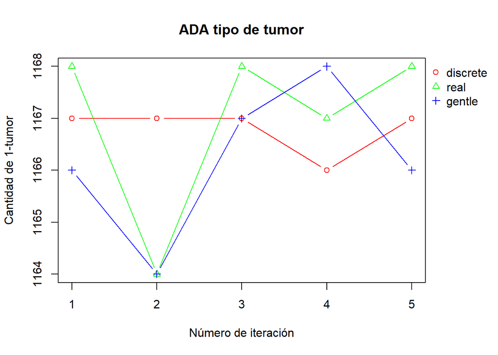

```r
library(traineR)
numero.filas <- nrow(datos)
cantidad.validacion.cruzada <- 5
cantidad.grupos <- 10

deteccion.no.discrete <- c()
deteccion.no.real <- c()
deteccion.no.gentle <- c()

for(i in 1:cantidad.validacion.cruzada){
  grupos  <- createFolds(1:numero.filas, cantidad.grupos)  # Crea los 10 grupos
  no.discrete <- 0
  no.real <- 0
  no.gentle <- 0

  # Este ciclo es el que hace 'cross-validation' (validación cruzada) con 10
  # grupos (Folds)
  for(k in 1:cantidad.grupos) {
    muestra <- grupos[[k]]  # Por ser una lista requiere de doble paréntesis
    ttesting <- datos[muestra, ]
    taprendizaje <- datos[-muestra, ]

    modelo<-train.ada(tipo~.,data=taprendizaje,iter=80,nu=1,type="discrete")
    prediccion <- predict(modelo, ttesting)
    MC <- confusion.matrix(ttesting, prediccion)
    no.discrete <- no.discrete + MC[2,2] ###para determinar los 1s, MC[1,1] seria 0s

    modelo<-train.ada(tipo~.,data=taprendizaje,iter=80,nu=1,type="real")
    prediccion <- predict(modelo, ttesting)
    MC <- confusion.matrix(ttesting, prediccion)
    no.real <- no.real + MC[2,2] ###para determinar los 1s

    modelo<-train.ada(tipo~.,data=taprendizaje,iter=80,nu=1,type="gentle")
    prediccion <- predict(modelo, ttesting)
    MC <- confusion.matrix(ttesting, prediccion)
    no.gentle <- no.gentle + MC[2,2] ###para determinar los 1s

  }

  deteccion.no.discrete[i] <- no.discrete
  deteccion.no.real[i] <- no.real
  deteccion.no.gentle[i] <- no.gentle
}

resultados <- data.frame("discrete"     = deteccion.no.discrete,
                         "real"     = deteccion.no.real,
                         "gentle" = deteccion.no.gentle) # Preparamos los datos

par(oma=c(0, 0, 0, 3)) # Hace espacio para la leyenda

matplot(resultados, type="b", lty = 1, lwd = 1, pch = 1:ncol(resultados),
        main = "ADA tipo de tumor",
        xlab = "Número de iteración",
        ylab = "Cantidad de 1-tumor",
        col = rainbow(ncol(resultados)))
legend(par('usr')[2], par('usr')[4], legend = colnames(resultados),bty='n', xpd=NA,
       pch=1:ncol(resultados), col = rainbow(ncol(resultados))) # La leyenda
```

2. Repita el ejercicio anterior, pero esta vez en lugar de sumar la cantidad de 1’s, promedie los errores globales cometidos en los diferentes grupos (folds). Luego grafique las 5 iteraciones para los tres algoritmos en el mismo gr´afico. ¿Se puede determinar con claridad cu´al algoritmo es el mejor?

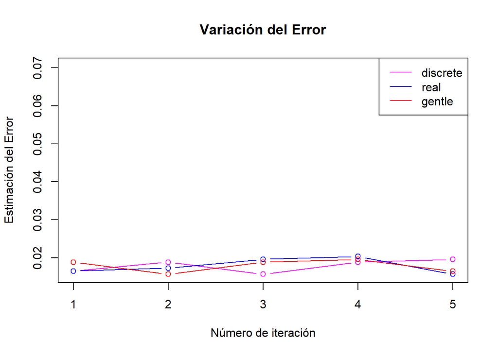

```r
# install.packages("caret",dependencies=TRUE)
suppressMessages(library(caret))

n <- dim(datos)[1] # Aquí n=150

v.error.discrete<-rep(0,5)
for(i in 1:5) {
  errori <- 0
  grupos <- createFolds(1:n,10) # grupos$Fold0i es el i-ésimo grupo
  for(k in 1:10) {
      muestra <- grupos[[k]] # Por ser una lista requiere de doble paréntesis
      ttesting <- datos[muestra,]
      taprendizaje <- datos[-muestra,]
      modelo <- train.ada(tipo~.,data=taprendizaje,iter=80,nu=1,type="discrete")
      prediccion <- predict(modelo,ttesting,type = "class")
      MC <- confusion.matrix(ttesting, prediccion)
      # Porcentaje de buena clasificación y de error
      acierto<-sum(diag(MC))/sum(MC)
      error <- 1 - acierto
      errori <- errori + error
  }
  v.error.discrete[i] <- errori/10
}

v.error.real<-rep(0,5)
for(i in 1:5) {
  errori <- 0
  grupos <- createFolds(1:n,10) # grupos$Fold0i es el i-ésimo grupo
  for(k in 1:10) {
      muestra <- grupos[[k]] # Por ser una lista requiere de doble paréntesis
      ttesting <- datos[muestra,]
      taprendizaje <- datos[-muestra,]
      modelo <- train.ada(tipo~.,data=taprendizaje,iter=80,nu=1,type="real")
      prediccion <- predict(modelo,ttesting,type = "class")
      MC <- confusion.matrix(ttesting, prediccion)
      # Porcentaje de buena clasificación y de error
      acierto<-sum(diag(MC))/sum(MC)
      error <- 1 - acierto
      errori <- errori + error
  }
  v.error.real[i] <- errori/10
}


v.error.gentle<-rep(0,5)
for(i in 1:5) {
  errori <- 0
  grupos <- createFolds(1:n,10) # grupos$Fold0i es el i-ésimo grupo
  for(k in 1:10) {
      muestra <- grupos[[k]] # Por ser una lista requiere de doble paréntesis
      ttesting <- datos[muestra,]
      taprendizaje <- datos[-muestra,]
      modelo <- train.ada(tipo~.,data=taprendizaje,iter=80,nu=1,type="gentle")
      prediccion <- predict(modelo,ttesting,type = "class")
      MC <- confusion.matrix(ttesting, prediccion)
      # Porcentaje de buena clasificación y de error
      acierto<-sum(diag(MC))/sum(MC)
      error <- 1 - acierto
      errori <- errori + error
  }
  v.error.gentle[i] <- errori/10
}


plot(v.error.discrete, col = "magenta", type = "b", ylim = c(min(v.error.discrete,v.error.real,v.error.gentle), max(v.error.discrete,
    v.error.real, v.error.gentle) + 0.05), main = "Variación del Error", xlab = "Número de iteración", ylab = "Estimación del Error")
points(v.error.real, col = "blue", type = "b")
points(v.error.gentle, col = "red", type = "b")
legend("topright", legend = c("discrete","real","gentle"), col = c("magenta",
    "blue","red"), lty = 1, lwd = 1)
```

3. ¿Cu´al algoritmo usar´ıa con base en la informaci´on obtenida en los dos ejercicios anteriores?

Ejercicio 3: [25 puntos] Para esta pregunta usaremos nuevamente los datos tumores.csv.

1. El objetivo de este ejercicio es calibrar el metodo de kknn para esta Tabla de Datos. Aqui interesa predecir en la variable tipo. Para esto genere 5 Validaciones Cruzadas con 10 grupos calibrando el modelo de acuerdo con todos los tipos de algoritmos que permite train.kknn en el par´ametro kernel, estos algoritmos son: rectangular, triangular, epanechnikov, biweight, triweight, cos, inv, gaussian y optimal. Para medir la calidad de m´etodo sume la cantidad de 1’s detectados en los diferentes grupos. Luego grafique las 5 iteraciones para todos algoritmos en el mismo gr´afico. ¿Se puede determinar con claridad cu´al algoritmo es el mejor?

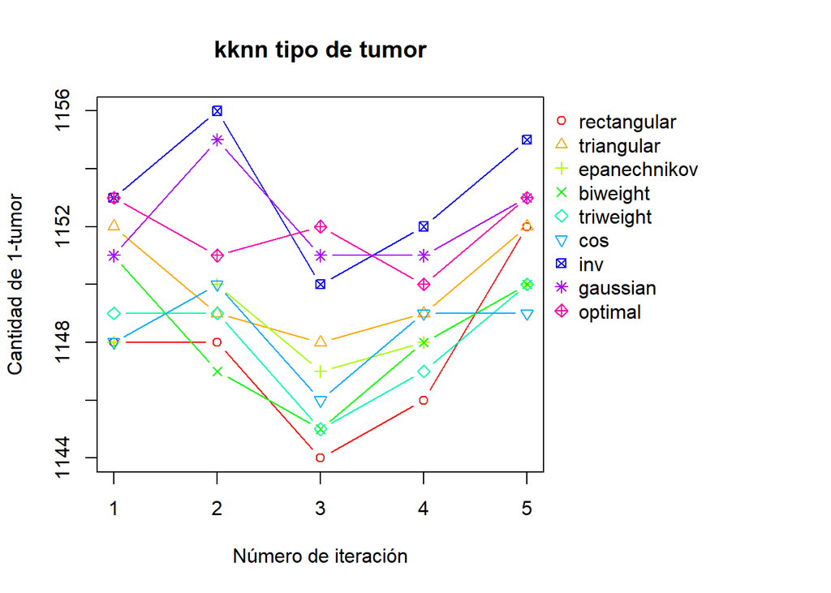

```r
library(traineR)
numero.filas <- nrow(datos)
cantidad.validacion.cruzada <- 5
cantidad.grupos <- 10

deteccion.no.rectangular <- c()
deteccion.no.triangular <- c()
deteccion.no.epanechnikov <- c()
deteccion.no.biweight <- c()
deteccion.no.triweight <- c()
deteccion.no.cos <- c()
deteccion.no.inv <- c()
deteccion.no.gaussian <- c()
deteccion.no.optimal <- c()

for(i in 1:cantidad.validacion.cruzada){
  grupos  <- createFolds(1:numero.filas, cantidad.grupos)
  no.rectangular <- 0
  no.triangular <- 0
  no.epanechnikov <- 0
  no.biweight <- 0
  no.triweight <- 0
  no.cos <- 0
  no.inv <- 0
  no.gaussian <- 0
  no.optimal <- 0

  for(k in 1:cantidad.grupos) {
    muestra <- grupos[[k]]
    ttesting <- datos[muestra, ]
    taprendizaje <- datos[-muestra, ]

    modelo<-train.knn(tipo~.,data=taprendizaje,kmax=10, kernel="rectangular")
    prediccion <- predict(modelo, ttesting,type = "class")
    MC <- confusion.matrix(ttesting, prediccion)
    no.rectangular <- no.rectangular + MC[2,2]

    modelo<-train.knn(tipo~.,data=taprendizaje,kmax=10, kernel="triangular")
    prediccion <- predict(modelo, ttesting,type = "class")
    MC <- confusion.matrix(ttesting, prediccion)
    no.triangular <- no.triangular + MC[2,2]

    modelo<-train.knn(tipo~.,data=taprendizaje,kmax=10, kernel="epanechnikov")
    prediccion <- predict(modelo, ttesting,type = "class")
    MC <- confusion.matrix(ttesting, prediccion)
    no.epanechnikov <- no.epanechnikov + MC[2,2]

    modelo<-train.knn(tipo~.,data=taprendizaje,kmax=10, kernel="biweight")
    prediccion <- predict(modelo, ttesting,type = "class")
    MC <- confusion.matrix(ttesting, prediccion)
    no.biweight <- no.biweight + MC[2,2]

    modelo<-train.knn(tipo~.,data=taprendizaje,kmax=10, kernel="triweight")
    prediccion <- predict(modelo, ttesting,type = "class")
    MC <- confusion.matrix(ttesting, prediccion)
    no.triweight <- no.triweight + MC[2,2]

    modelo<-train.knn(tipo~.,data=taprendizaje,kmax=10, kernel="cos")
    prediccion <- predict(modelo, ttesting,type = "class")
    MC <- confusion.matrix(ttesting, prediccion)
    no.cos <- no.cos + MC[2,2]

    modelo<-train.knn(tipo~.,data=taprendizaje,kmax=10, kernel="inv")
    prediccion <- predict(modelo, ttesting,type = "class")
    MC <- confusion.matrix(ttesting, prediccion)
    no.inv <- no.inv + MC[2,2]

    modelo<-train.knn(tipo~.,data=taprendizaje,kmax=10, kernel="gaussian")
    prediccion <- predict(modelo, ttesting,type = "class")
    MC <- confusion.matrix(ttesting, prediccion)
    no.gaussian <- no.gaussian + MC[2,2]

    modelo<-train.knn(tipo~.,data=taprendizaje,kmax=10, kernel="optimal")
    prediccion <- predict(modelo, ttesting,type = "class")
    MC <- confusion.matrix(ttesting, prediccion)
    no.optimal <- no.optimal + MC[2,2]

  }

  deteccion.no.rectangular[i] <- no.rectangular
  deteccion.no.triangular[i] <- no.triangular
  deteccion.no.epanechnikov[i] <- no.epanechnikov
  deteccion.no.biweight[i] <- no.biweight
  deteccion.no.triweight[i] <- no.triweight
  deteccion.no.cos[i] <- no.cos
  deteccion.no.inv[i] <- no.inv
  deteccion.no.gaussian[i] <- no.gaussian
  deteccion.no.optimal[i] <- no.optimal
}

resultados <- data.frame("rectangular" = deteccion.no.rectangular,
                         "triangular" = deteccion.no.triangular,
                         "epanechnikov" = deteccion.no.epanechnikov,
                         "biweight" = deteccion.no.biweight,
                         "triweight" = deteccion.no.triweight,
                         "cos" = deteccion.no.cos,
                         "inv" = deteccion.no.inv,
                         "gaussian" = deteccion.no.gaussian,
                         "optimal" = deteccion.no.optimal)

par(oma=c(0, 0, 0, 10)) # Hace espacio para la leyenda

matplot(resultados, type="b", lty = 1, lwd = 1, pch = 1:ncol(resultados),
        main = "kknn tipo de tumor",
        xlab = "Número de iteración",
        ylab = "Cantidad de 1-tumor",
        col = rainbow(ncol(resultados)))
legend(par('usr')[2], par('usr')[4], legend = colnames(resultados),bty='n', xpd=NA,
       pch=1:ncol(resultados), col = rainbow(ncol(resultados))) # La leyenda
```

2. Repita el ejercicio anterior, pero esta vez en lugar de sumar la cantidad de 1’s, promedie los errores globales cometidos en los diferentes grupos (folds). Luego grafique las 5 iteraciones para todos los algoritmos en el mismo gr´afico. ¿Se puede determinar con claridad cu´al algoritmo es el mejor?

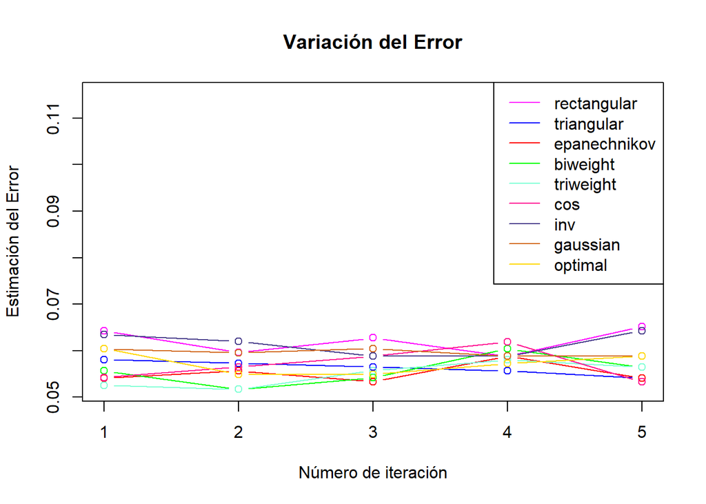

```r
suppressMessages(library(traineR))
suppressMessages(library(caret)) # Este paquete es usado para generar los grupos al azar

n <- dim(datos)[1] # Aquí n=150
## Vamos a generar el modelo dejando un grupo para testing y los demás datos para aprendizaje.
v.error.rectangular<-rep(0,5)
# Hacemos validación cruzada 10 veces para ver que el error se estabiliza
for(i in 1:5) {
  errori <- 0
  grupos <- createFolds(1:n,10) # grupos$Fold0i es el i-ésimo grupo
  for(k in 1:10) {
      muestra <- grupos[[k]] # Por ser una lista requiere de doble paréntesis
      ttesting <- datos[muestra,]
      taprendizaje <- datos[-muestra,]
      modelo <- train.knn(tipo~.,data=taprendizaje,kmax=10, kernel="rectangular")
      prediccion <- predict(modelo,ttesting,type = "class")
      MC <- confusion.matrix(ttesting, prediccion)
      # Porcentaje de buena clasificación y de error
      acierto<-sum(diag(MC))/sum(MC)
      error <- 1 - acierto
      errori <- errori + error
  }
  v.error.rectangular[i] <- errori/10
}


v.error.triangular<-rep(0,5)
for(i in 1:5) {
  errori <- 0
  grupos <- createFolds(1:n,10) # grupos$Fold0i es el i-ésimo grupo
  # Este ciclo es el que hace "cross-validation" (validación cruzada) con 5 grupos (Folds)
  for(k in 1:10) {
      muestra <- grupos[[k]] # Por ser una lista requiere de doble paréntesis
      ttesting <- datos[muestra,]
      taprendizaje <- datos[-muestra,]
      modelo <- train.knn(tipo~.,data=taprendizaje,kmax=10, kernel="triangular")
      prediccion <- predict(modelo,ttesting,type = "class")
      MC <- confusion.matrix(ttesting, prediccion)
      # Porcentaje de buena clasificación y de error
      acierto<-sum(diag(MC))/sum(MC)
      error <- 1 - acierto
      errori <- errori + error
  }
  v.error.triangular[i] <- errori/10
}

v.error.epanechnikov<-rep(0,5)
for(i in 1:5) {
  errori <- 0
  # Esta instrucción genera los k=5 grupos (Folds)
  grupos <- createFolds(1:n,10) # grupos$Fold0i es el i-ésimo grupo
  # Este ciclo es el que hace "cross-validation" (validación cruzada) con 5 grupos (Folds)
  for(k in 1:10) {
      muestra <- grupos[[k]] # Por ser una lista requiere de doble paréntesis
      ttesting <- datos[muestra,]
      taprendizaje <- datos[-muestra,]
      modelo <- train.knn(tipo~.,data=taprendizaje,kmax=10, kernel="epanechnikov")
      prediccion <- predict(modelo,ttesting,type = "class")
      MC <- confusion.matrix(ttesting, prediccion)
      # Porcentaje de buena clasificación y de error
      acierto<-sum(diag(MC))/sum(MC)
      error <- 1 - acierto
      errori <- errori + error
  }
  v.error.epanechnikov[i] <- errori/10
}


v.error.biweight<-rep(0,5)
for(i in 1:5) {
  errori <- 0
  # Esta instrucción genera los k=5 grupos (Folds)
  grupos <- createFolds(1:n,10) # grupos$Fold0i es el i-ésimo grupo
  # Este ciclo es el que hace "cross-validation" (validación cruzada) con 5 grupos (Folds)
  for(k in 1:10) {
      muestra <- grupos[[k]] # Por ser una lista requiere de doble paréntesis
      ttesting <- datos[muestra,]
      taprendizaje <- datos[-muestra,]
      modelo <- train.knn(tipo~.,data=taprendizaje,kmax=10, kernel="biweight")
      prediccion <- predict(modelo,ttesting,type = "class")
      MC <- confusion.matrix(ttesting, prediccion)
      acierto<-sum(diag(MC))/sum(MC)
      error <- 1 - acierto
      errori <- errori + error
  }
  v.error.biweight[i] <- errori/10
}


v.error.triweight<-rep(0,5)
# Hacemos validación cruzada 10 veces para ver que el error se estabiliza
for(i in 1:5) {
  errori <- 0
  grupos <- createFolds(1:n,10) # grupos$Fold0i es el i-ésimo grupo
  for(k in 1:10) {
      muestra <- grupos[[k]] # Por ser una lista requiere de doble paréntesis
      ttesting <- datos[muestra,]
      taprendizaje <- datos[-muestra,]
      modelo <- train.knn(tipo~.,data=taprendizaje,kmax=10, kernel="triweight")
      prediccion <- predict(modelo,ttesting,type = "class")
      MC <- confusion.matrix(ttesting, prediccion)
      # Porcentaje de buena clasificación y de error
      acierto<-sum(diag(MC))/sum(MC)
      error <- 1 - acierto
      errori <- errori + error
  }
  v.error.triweight[i] <- errori/10
}


v.error.cos<-rep(0,5)
for(i in 1:5) {
  errori <- 0
  grupos <- createFolds(1:n,10) # grupos$Fold0i es el i-ésimo grupo
  for(k in 1:10) {
      muestra <- grupos[[k]] # Por ser una lista requiere de doble paréntesis
      ttesting <- datos[muestra,]
      taprendizaje <- datos[-muestra,]
      modelo <- train.knn(tipo~.,data=taprendizaje,kmax=10, kernel="cos")
      prediccion <- predict(modelo,ttesting,type = "class")
      MC <- confusion.matrix(ttesting, prediccion)
      # Porcentaje de buena clasificación y de error
      acierto<-sum(diag(MC))/sum(MC)
      error <- 1 - acierto
      errori <- errori + error
  }
  v.error.cos[i] <- errori/10
}


v.error.inv<-rep(0,5)
for(i in 1:5) {
  errori <- 0
  grupos <- createFolds(1:n,10) # grupos$Fold0i es el i-ésimo grupo
  for(k in 1:10) {
      muestra <- grupos[[k]] # Por ser una lista requiere de doble paréntesis
      ttesting <- datos[muestra,]
      taprendizaje <- datos[-muestra,]
      modelo <- train.knn(tipo~.,data=taprendizaje,kmax=10, kernel="inv")
      prediccion <- predict(modelo,ttesting,type = "class")
      MC <- confusion.matrix(ttesting, prediccion)
      # Porcentaje de buena clasificación y de error
      acierto<-sum(diag(MC))/sum(MC)
      error <- 1 - acierto
      errori <- errori + error
  }
  v.error.inv[i] <- errori/10
}



v.error.gaussian<-rep(0,5)
for(i in 1:5) {
  errori <- 0
  grupos <- createFolds(1:n,10) # grupos$Fold0i es el i-ésimo grupo
  for(k in 1:10) {
      muestra <- grupos[[k]] # Por ser una lista requiere de doble paréntesis
      ttesting <- datos[muestra,]
      taprendizaje <- datos[-muestra,]
      modelo <- train.knn(tipo~.,data=taprendizaje,kmax=10, kernel="gaussian")
      prediccion <- predict(modelo,ttesting,type = "class")
      MC <- confusion.matrix(ttesting, prediccion)
      # Porcentaje de buena clasificación y de error
      acierto<-sum(diag(MC))/sum(MC)
      error <- 1 - acierto
      errori <- errori + error
  }
  v.error.gaussian[i] <- errori/10
}


v.error.optimal<-rep(0,5)
for(i in 1:5) {
  errori <- 0
  grupos <- createFolds(1:n,10) # grupos$Fold0i es el i-ésimo grupo
  for(k in 1:10) {
      muestra <- grupos[[k]] # Por ser una lista requiere de doble paréntesis
      ttesting <- datos[muestra,]
      taprendizaje <- datos[-muestra,]
      modelo <- train.knn(tipo~.,data=taprendizaje,kmax=10, kernel="optimal")
      prediccion <- predict(modelo,ttesting,type = "class")
      MC <- confusion.matrix(ttesting, prediccion)
      # Porcentaje de buena clasificación y de error
      acierto<-sum(diag(MC))/sum(MC)
      error <- 1 - acierto
      errori <- errori + error
  }
  v.error.optimal[i] <- errori/10
}


plot(v.error.rectangular, col = "magenta", type = "b", ylim = c(min(v.error.rectangular, v.error.triangular,v.error.epanechnikov,v.error.biweight,v.error.triweight, v.error.cos, v.error.inv, v.error.gaussian, v.error.optimal), max(v.error.rectangular, v.error.triangular,v.error.epanechnikov,v.error.biweight,v.error.triweight, v.error.cos, v.error.inv, v.error.gaussian, v.error.optimal) + 0.05), main = "Variación del Error", xlab = "Número de iteración", ylab = "Estimación del Error")
points(v.error.triangular, col = "blue", type = "b")
points(v.error.epanechnikov, col = "red", type = "b")
points(v.error.biweight, col = "green", type = "b")
points(v.error.triweight, col = "aquamarine", type = "b")
points(v.error.cos, col = "deeppink1", type = "b")
points(v.error.inv, col = "darkslateblue", type = "b")
points(v.error.gaussian, col = "chocolate", type = "b")
points(v.error.optimal, col = "gold", type = "b")
legend("topright", legend = c("rectangular","triangular","epanechnikov","biweight", "triweight", "cos", "inv", "gaussian", "optimal"), col = c("magenta", "blue","red","green", "aquamarine", "deeppink1", "darkslateblue", "chocolate", "gold"), lty = 1, lwd = 1)
```

3. ¿Cu´al algoritmo usar´ıa con base en la informaci´on obtenida en los dos ejercicios anteriores?

Ejercicio 4: [25 puntos] Esta pregunta tambi´en utilizan nuevamente los datos tumores.csv.

1. El objetivo de este ejercicio es comparar todos los m´etodos predictivos vistos en el curso con esta tabla de datos. Aqu´ı interesa predecir en la variable tipo, para esto genere 5 Validaciones Cruzadas con 10 grupos para los m´etodos SVM, KNN, ´Arboles, Bosques, Potenciaci´on, eXtreme Gradient Boosting, LDA, Bayes, Regresi´on Log´ıstica, ConsensoPropio y Redes Neuronales, para KNN y Potenciaci´on use los par´ametros obtenidos en las calibraciones realizadas en los ejercicios anteriores. Luego grafique las 5 iteraciones para todos los m´etodos en el mismo gr´afico. ¿Se puede determinar con claridad cu´al m´etodos es el mejor?

```r
indices.general <- function(MC) {
  precision.global <- sum(diag(MC))/sum(MC)
  error.global <- 1 - precision.global
  precision.categoria <- diag(MC)/rowSums(MC)
  precision.positiva <- MC[2, 2]/(MC[2, 2] + MC[2, 1])
  precision.negativa <- MC[1, 1]/(MC[1, 1] + MC[1, 2])
  falsos.positivos <- 1 - precision.negativa
  falsos.negativos <- 1 - precision.positiva
  asertividad.positiva <- MC[2, 2]/(MC[1, 2] + MC[2, 2])
  asertividad.negativa <- MC[1, 1]/(MC[1, 1] + MC[2, 1])
  res <- list(matriz.confusion = MC, precision.global = precision.global, error.global = error.global,
              precision.categoria = precision.categoria, precision.positiva = precision.positiva, precision.negativa=precision.negativa,
              falsos.positivos=falsos.positivos, falsos.negativos=falsos.negativos, asertividad.positiva=asertividad.positiva,
              asertividad.negativa=asertividad.negativa)
  names(res) <- c("Matriz de Confusión", "Precisión Global", "Error Global", "Precisión por categoría", "Precision Positiva", "Precision Negativa",
                  "Falsos Positivos", "Falsos Negativos", "Asertividad Positiva", "Asertividad Negativa")
  return(res)
}


library(e1071)
library(kknn)
library(MASS)
library(class)
library(rpart)
library(randomForest)
library(ada)
library(nnet)
library(caret)
library(traineR)

setwd("C:/Users/rzamoram/Documents/Machine Learning/Mineria de Datos I/Clase2")
data1<-read.csv("tumores.csv",dec='.',header=T)
data1$tipo <- factor(data1$tipo,ordered = TRUE)
datos <- data1[,-1]
```

```r
indices.general <- function(MC) {
  precision.global <- sum(diag(MC))/sum(MC)
  error.global <- 1 - precision.global
  precision.categoria <- diag(MC)/rowSums(MC)
  precision.positiva <- MC[2, 2]/(MC[2, 2] + MC[2, 1])
  precision.negativa <- MC[1, 1]/(MC[1, 1] + MC[1, 2])
  falsos.positivos <- 1 - precision.negativa
  falsos.negativos <- 1 - precision.positiva
  asertividad.positiva <- MC[2, 2]/(MC[1, 2] + MC[2, 2])
  asertividad.negativa <- MC[1, 1]/(MC[1, 1] + MC[2, 1])
  res <- list(matriz.confusion = MC, precision.global = precision.global, error.global = error.global,
              precision.categoria = precision.categoria, precision.positiva = precision.positiva, precision.negativa=precision.negativa,
              falsos.positivos=falsos.positivos, falsos.negativos=falsos.negativos, asertividad.positiva=asertividad.positiva,
              asertividad.negativa=asertividad.negativa)
  names(res) <- c("Matriz de Confusión", "Precisión Global", "Error Global", "Precisión por categoría", "Precision Positiva", "Precision Negativa",
                  "Falsos Positivos", "Falsos Negativos", "Asertividad Positiva", "Asertividad Negativa")
  return(res)
}




datos$tipo <- factor(datos$tipo,ordered = TRUE)


numero.filas <- nrow(datos)
cantidad.validacion.cruzada <- 5
cantidad.grupos <- 10

deteccion.no.svm <- c()
deteccion.no.knn <- c()
deteccion.no.bayes <- c()
deteccion.no.arbol <- c()
deteccion.no.bosque <- c()
deteccion.no.potenciacion <- c()
deteccion.no.red <- c()
deteccion.no.xgboost <- c()
deteccion.no.red.neu <- c()
deteccion.no.glm <- c()
deteccion.no.ada <- c()
deteccion.no.consenso <- c()



deteccion.error.svm <- c()
deteccion.error.knn <- c()
deteccion.error.bayes <- c()
deteccion.error.arbol <- c()
deteccion.error.bosque <- c()
deteccion.error.potenciacion <- c()
deteccion.error.red <- c()
deteccion.error.xgboost <- c()
deteccion.error.red.neu <- c()
deteccion.error.glm <- c()
deteccion.erro.ada <- c()
deteccion.error.consenso <- c()

# Validación cruzada 5 veces
for (i in 1:cantidad.validacion.cruzada) {
  grupos <- createFolds(1:numero.filas, cantidad.grupos) # Crea los 10 grupos
  no.svm <- 0
  no.knn <- 0
  no.bayes <- 0
  no.arbol <- 0
  no.bosque <- 0
  no.potenciacion <- 0
  no.red <- 0
  no.xg  <- 0
  no.red.neu <- 0
  no.glm <- 0
  no.ada <- 0
  no.consenso <- 0


  error.svm <- 0
  error.knn <- 0
  error.bayes <- 0
  error.arbol <- 0
  error.bosque <- 0
  error.potenciacion <- 0
  error.red <- 0
  error.xg  <- 0
  error.red.neu <- 0
  error.glm <- 0
  error.ada <- 0
  error.consenso <- 0
  # Este ciclo es el que hace validación cruzada con 10 grupos
  for (k in 1:cantidad.grupos) {
    muestra <- grupos[[k]] # Por ser una lista requiere de doble paréntesis
    ttesting <- datos[muestra, ]
    ttraining <- datos[-muestra, ]

    consenso <- function(ttraining){
      largo <- dim(ttraining)[1]
      m1 <- sample(1:largo, replace=TRUE)
      ap1 <- ttraining[m1,]
      m2 <- sample(1:largo, replace=TRUE)
      ap2 <- ttraining[m2,]
      m3 <- sample(1:largo, replace=TRUE)
      ap3 <- ttraining[m3,]
      m4 <- sample(1:largo, replace=TRUE)
      ap4 <- ttraining[m4,]
      m5 <- sample(1:largo, replace=TRUE)
      ap5 <- ttraining[m5,]
      m6 <- sample(1:largo, replace=TRUE)
      ap6 <- ttraining[m6,]

      m9 <- sample(1:largo, replace=TRUE)
      ap9 <- ttraining[m9,]



      mod.knn<-train.kknn(tipo~., data = ap1 , kmax=10)
      mod.redes<-nnet(tipo~ ., data = ap2, size = 4, rang= 0.1, decay = 5e-04,maxit = 500, trace = FALSE, MaxNWts=1500)
      mod.arboles<-rpart(tipo ~ ., data = ap3)
      mod.svm.1<-svm(tipo~ ., data = ap4, kernel="radial")
      mod.svm.2<-svm(tipo~ ., data = ap5, kernel="polynomial")
      mod.bayes <- naiveBayes(tipo~.,data=ap6)

      #mod.qda <- qda(Survived~., data=ap8)
      mod.ada<-ada(tipo~.,data=ap9,iter=10,nu=0.9)

      mod.consenso <- list(kvecinos=mod.knn,red.neuronal=mod.redes,arbol.decision=mod.arboles,SVM1=mod.svm.1,SVM2=mod.svm.2,bayes=mod.bayes,boosting=mod.ada)
      return(list(kvecinos=mod.knn,red.neuronal=mod.redes,arbol.decision=mod.arboles,SVM1=mod.svm.1,SVM2=mod.svm.2,bayes=mod.bayes,boosting=mod.ada))
    }


    library(modeest)
    predice<-function(ttesting,mod.consenso){
      p.knn<-as.numeric(predict(mod.consenso$kvecinos, ttesting))
      p.red<-as.numeric(predict(mod.consenso$red.neuronal, ttesting, type = "class"))
      p.arbol<-as.numeric(predict(mod.consenso$arbol.decision, ttesting, type = "class"))
      p.svm1<-as.numeric(predict(mod.consenso$SVM1, ttesting, type = "class"))
      p.bayes <-as.numeric(predict(mod.consenso$bayes,ttesting))

      auxiliar <- p.knn-1

      votos<-data.frame(p.knn,p.red,p.arbol,p.svm1,p.bayes)
      votos$p.knn<-votos$p.knn-1
      votos$p.arbol<-votos$p.arbol-1
      votos$p.svm1<-votos$p.svm1-1
      votos$p.bayes<-votos$p.bayes-1


      modas <-  rep(0,dim(votos)[1])
      for (i in 1:dim(votos)[1]){
        modas[i]<-mfv(as.numeric(votos[i,]))
      }
      confusion<-table(ttesting$tipo,modas)
      return(confusion)

    }

    mod.consenso <- consenso(ttraining)
    pred.consenso<-predice(ttesting,mod.consenso)
    MC <- indices.general(pred.consenso)
    no.consenso <- no.consenso + MC$`Matriz de Confusión`["1","1"]
    error.consenso <- error.consenso +(1-(sum(diag(MC$`Matriz de Confusión`)))/sum(MC$`Matriz de Confusión`))*100




    modelo <- train.svm(tipo ~ ., data = ttraining, kernel = "radial", probability = FALSE)
    prediccion <- predict(modelo, ttesting)
    MC <- confusion.matrix(ttesting, prediccion)
    no.svm <- no.svm + MC[2,2] # Detección de los No Pagadores
    error.svm<-error.svm+(1-(sum(diag(MC)))/sum(MC))*100

    modelo <- train.knn(tipo ~ ., data = ttraining, kmax = 37, kernel="biweight")
    prediccion <- predict(modelo, ttesting)
    MC <- confusion.matrix(ttesting, prediccion)
    no.knn <- no.knn + MC[2,2] # Detección de los No Pagadores
    error.knn <- error.knn+(1-(sum(diag(MC)))/sum(MC))*100

    modelo <- train.bayes(tipo ~ ., data = ttraining)
    prediccion <- predict(modelo, ttesting)
    MC <- confusion.matrix(ttesting, prediccion)
    no.bayes <- no.bayes + MC[2,2] # Detección de los No Pagadores
    error.bayes <- error.bayes+(1-(sum(diag(MC)))/sum(MC))*100

    modelo = train.rpart(tipo ~ ., data = ttraining)
    prediccion <- predict(modelo, ttesting)
    MC <- confusion.matrix(ttesting, prediccion)
    no.arbol <- no.arbol + MC[2,2] # Detección de los No Pagadores
    error.arbol <- error.arbol+(1-(sum(diag(MC)))/sum(MC))*100

    modelo <- train.randomForest(tipo ~ ., data = ttraining)
    prediccion <- predict(modelo, ttesting)
    MC <- confusion.matrix(ttesting, prediccion)
    no.bosque <- no.bosque + MC[2,2] # Detección de los No Pagadores
    error.bosque <- error.bosque+(1-(sum(diag(MC)))/sum(MC))*100

    modelo <- train.ada(tipo ~ ., data = ttraining, iter = 20, nu = 1, type = "discrete")
    prediccion <- predict(modelo, ttesting)
    MC <- confusion.matrix(ttesting, prediccion)
    no.potenciacion <- no.potenciacion + MC[2,2] # Detección de los No Pagadores
    error.potenciacion <- error.potenciacion+(1-(sum(diag(MC)))/sum(MC))*100

    modelo <- train.nnet(tipo ~ ., data = ttraining, size = 100, MaxNWts = 5000, rang = 0.01,
               decay = 5e-4, maxit = 45, trace = TRUE)
    prediccion <- predict(modelo, ttesting)
    MC <- confusion.matrix(ttesting, prediccion)
    no.red <- no.red + MC[2,2] # Detección de los No Pagadores
    error.red <- error.red+(1-(sum(diag(MC)))/sum(MC))*100

    modelo <- train.xgboost(tipo ~ ., data = ttraining, nrounds = 79,
                        print_every_n = 10, maximize = F , eval_metric = "error")
    prediccion <- predict(modelo, ttesting)
    MC <- confusion.matrix(ttesting, prediccion)
    no.xg <- no.xg + MC[2,2] # Detección de los No Pagadores
    error.xg <- error.xg+(1-(sum(diag(MC)))/sum(MC))*100

    modelo <- train.neuralnet(tipo ~., data = ttraining, hidden = c(8,6,4),
                          linear.output = FALSE, threshold = 0.5, stepmax = 1e+06)
    prediccion <- predict(modelo, ttesting)
    MC <- confusion.matrix(ttesting, prediccion)
    no.red.neu <- no.red.neu + MC[2,2] # Detección de los No Pagadores
    error.red.neu <- error.red.neu+(1-(sum(diag(MC)))/sum(MC))*100

    modelo <- train.glm(tipo ~ ., data = ttraining)
    prediccion <- predict(modelo, ttesting)
    MC <- confusion.matrix(ttesting, prediccion)
    no.glm <- no.glm + MC[2,2] # Detección de los No Pagadores
    error.glm <- error.glm+(1-(sum(diag(MC)))/sum(MC))*100

    modelo<-train.ada(tipo~.,data=ttraining,iter=80,nu=1,type="gentle")
    prediccion <- predict(modelo, ttesting)
    MC <- confusion.matrix(ttesting, prediccion)
    no.ada <- no.ada + MC[2,2] ###para determinar los 1s
    error.ada <- error.ada+(1-(sum(diag(MC)))/sum(MC))*100
  }
  deteccion.no.svm[i] <- no.svm
  deteccion.no.knn[i] <- no.knn
  deteccion.no.bayes[i] <- no.bayes
  deteccion.no.arbol[i] <- no.arbol
  deteccion.no.bosque[i] <- no.bosque
  deteccion.no.potenciacion[i] <- no.potenciacion
  deteccion.no.red[i] <- no.red
  deteccion.no.xgboost[i] <- no.xg
  deteccion.no.red.neu[i] <- no.red.neu
  deteccion.no.glm[i] <- no.glm
  deteccion.no.ada[i] <- no.ada
  deteccion.no.consenso[i] <- no.consenso

  deteccion.error.svm[i] <- error.svm/cantidad.grupos
  deteccion.error.knn[i] <- error.knn/cantidad.grupos
  deteccion.error.bayes[i] <- error.bayes/cantidad.grupos
  deteccion.error.arbol[i] <- error.arbol/cantidad.grupos
  deteccion.error.bosque[i] <- error.bosque/cantidad.grupos
  deteccion.error.potenciacion[i] <- error.potenciacion/cantidad.grupos
  deteccion.error.red[i] <- error.red/cantidad.grupos
  deteccion.error.xgboost[i] <- error.xg/cantidad.grupos
  deteccion.error.red.neu[i] <- error.red.neu/cantidad.grupos
  deteccion.error.glm[i] <- error.glm/cantidad.grupos
  deteccion.error.ada[i] <- error.ada/cantidad.grupos
  deteccion.error.consenso[i] <- error.consenso/cantidad.grupos
}
```

```
## Error in eval(expr, envir, enclos): object 'deteccion.error.ada' not found
```

```r
resultados <- data.frame("svm" = deteccion.no.svm,
                         "k_vecinos" = deteccion.no.knn,
                         "bayes" = deteccion.no.bayes,
                         "arboles" = deteccion.no.arbol,
                         "bosques" = deteccion.no.bosque,
                         "potenciacion" = deteccion.no.potenciacion,
                         "redes_nnet" = deteccion.no.red,
                         "xgboost" = deteccion.no.xgboost,
                         "redes_neuralnet" = no.red.neu,
                         "regresion_logistica" = deteccion.no.glm,
                         "ada" = no.red.ada,
                         "consenso" = deteccion.no.consenso)
```

```
## Error in data.frame(svm = deteccion.no.svm, k_vecinos = deteccion.no.knn, : object 'no.red.ada' not found
```

```r
resultados1 <- data.frame("svm" = deteccion.error.svm,
                         "k_vecinos" = deteccion.error.knn,
                         "bayes" = deteccion.error.bayes,
                         "arboles" = deteccion.error.arbol,
                         "bosques" = deteccion.error.bosque,
                         "potenciacion" = deteccion.error.potenciacion,
                         "redes_nnet" = deteccion.error.red,
                         "xgboost" = deteccion.error.xgboost,
                         "redes_neuralnet" = deteccion.error.red.neu,
                         "regresion_logistica" = deteccion.error.glm,
                         "ada" = deteccion.error.ada,
                         "consenso" = deteccion.error.consenso)
```

```
## Error in data.frame(svm = deteccion.error.svm, k_vecinos = deteccion.error.knn, : object 'deteccion.error.ada' not found
```

[figure not shown]

```r
par(oma=c(0, 0, 0, 8)) # Hace espacio para la leyenda

matplot(resultados, type="b", lty = 1, lwd = 1, pch = 1:ncol(resultados),
        main = "Detección del 1-tumor",
        xlab = "Número de iteración",
        ylab = "Cantidad de 1-tumor detectados",
        col = rainbow(ncol(resultados)))
legend(par('usr')[2], par('usr')[4], legend = colnames(resultados),bty='n', xpd=NA,
       pch=1:ncol(resultados), col = rainbow(ncol(resultados))) # La leyenda
```

2. Repita el ejercicio anterior, pero en lugar de sumar la cantidad de 1’s, promedie los errores globales cometidos en los diferentes grupos (folds). Luego grafique las 5 iteraciones para todos los m´etodos vistos en el curso en el mismo gr´afico. ¿Se puede determinar con claridad cu´al algoritmo es el mejor?

```r
par(oma=c(0, 0, 0, 8)) # Hace espacio para la leyenda
matplot(resultados1, type="b", lty = 1, lwd = 1, pch = 1:ncol(resultados),
        main = "Comparación del Error Global",
        xlab = "Número de iteración",
        ylab = "Porcentaje de Error Global",
        col = rainbow(ncol(resultados)))
```

[output not shown]

```
## Error in matplot(resultados1, type = "b", lty = 1, lwd = 1, pch = 1:ncol(resultados), : object 'resultados1' not found
```

```r
legend(par('usr')[2], par('usr')[4], legend = colnames(resultados),bty='n', xpd=NA, cex = 0.8,
       pch=1:ncol(resultados), col = rainbow(ncol(resultados))) # La leyenda
```

```
## Error in strwidth(legend, units = "user", cex = cex, font = text.font): plot.new has not been called yet
```

3. ¿Cu´al m´etodo usar´ıa con base en la informaci´on obtenida en los dos ejercicios anteriores?